# FordGoBike

## by Mayar Mohsen

## Investigation Overview

> *In this presentation, we will focus on the member genders (Males, Females, Others) and user type (Customer, Subscriber) and see the difference between them in member birth year and trips duration*

## Dataset Overview

> *This data set includes information about individual rides made in a bike-sharing system covering the greater San Francisco Bay area*

## Member gender

- Males have the greatest number then females then others

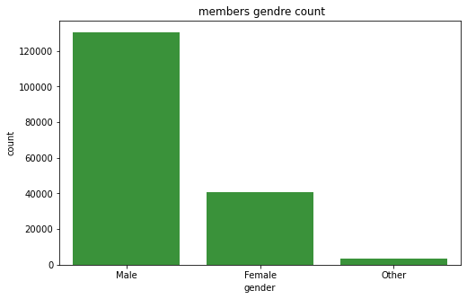

```python
plt.figure(figsize=[8,5])
base_color = sb.color_palette()[2]
sb.countplot(data = df, x='member_gender', color=base_color)

plt.title(' members gendre count')
plt.xlabel('gender')
plt.ylabel('count')
```

## Member gender VS. Member birth year

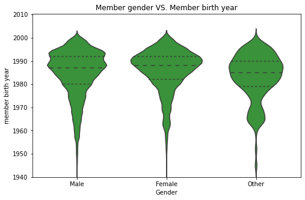

```python
plt.figure(figsize=[8,5])
sb.violinplot(data=df, x='member_gender', y='member_birth_year', inner ='quartile' ,  color = base_color)
plt.ylim(1940)

plt.title('Member gender VS. Member birth year')
plt.xlabel('Gender')
plt.ylabel('member birth year')
```

## Member gender VS. Duration

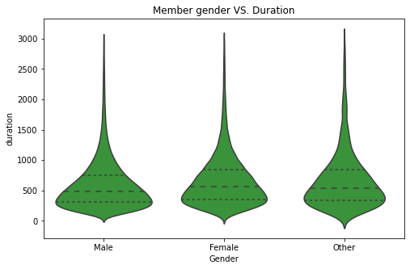

```python
plt.figure(figsize=[8,5])
df_edited = df.query('duration_sec < 3000')
sb.violinplot(data=df_edited, x='member_gender', y='duration_sec', inner ='quartile' ,  color = base_color)

plt.title('Member gender VS. Duration')
plt.xlabel('Gender')
plt.ylabel('duration')
```

## Member birth year VS. Duration VS. Member gender

> - Males born from 1980 to 2000 mostly have trips from 0 to 500 seconds
> - Females born from 1980 to 2000 mostly have trips from 0 to 1000 seconds
> - Others born from 1975 to 2000 mostly have trips from 0 to 1000 seconds

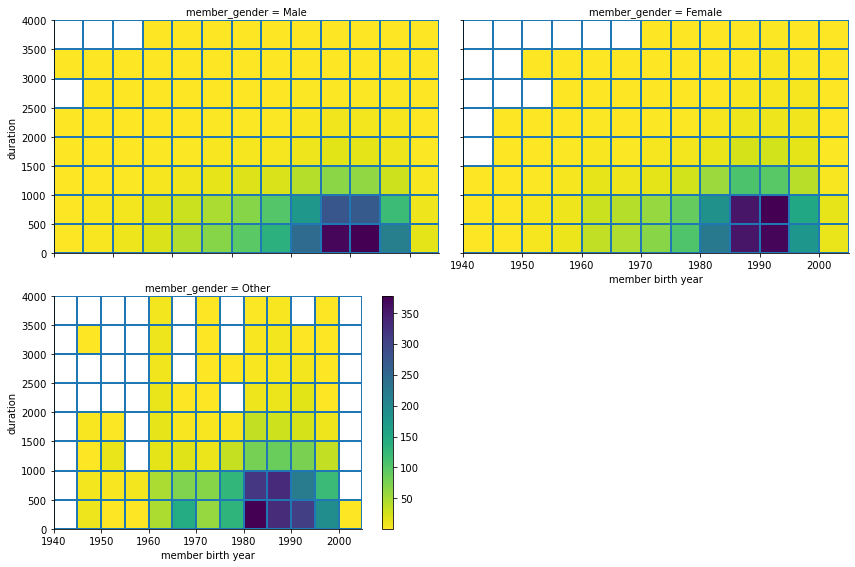

```python
bins_x = np.arange(1940, df['member_birth_year'].max()+5,5)
bins_y = np.arange(0, 4000+500,500)

g = sb.FacetGrid(data=df, col='member_gender', size=4, aspect=1.5, col_wrap=2)
g.map(plt.hist2d, 'member_birth_year', 'duration_sec',bins=[bins_x,bins_y], cmin=0.5, cmap='viridis_r')
plt.colorbar()

g.set_xlabels('member birth year')
g.set_ylabels('duration')
```

## User types

- Number of subscribers is much greater than number of customers

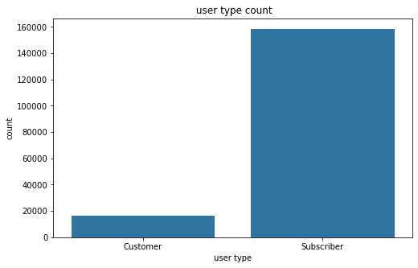

```python
plt.figure(figsize=[8,5])
base_color = sb.color_palette()[0]
sb.countplot(data = df, x='user_type', color=base_color)

plt.title(' user type count')
plt.xlabel('user type')
plt.ylabel('count')
```

## User type VS. Member birth year

- Both the customers and subscribers are the same

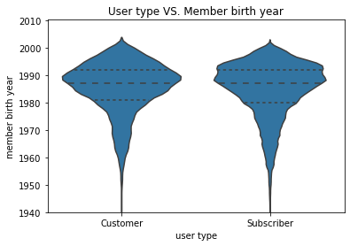

```python
sb.violinplot(data=df, x='user_type', y='member_birth_year', color=base_color, inner='quartile')
plt.ylim(1940)
plt.title('User type VS. Member birth year')
plt.xlabel('user type')
plt.ylabel('member birth year')
```

## User type VS. Duration

> - subiscribers have a shortest duration trips than the customers

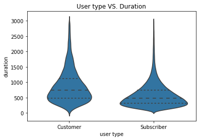

```python
sb.violinplot(data=df_edited, x='user_type', y='duration_sec', color=base_color, inner='quartile')

plt.title('User type VS. Duration')
plt.xlabel('user type')
plt.ylabel('duration')
```

## Member birth year VS. Duration VS. User type

> - Customers born from 1980 to 2000 mostly have trips from 500 to 1000 seconds
> - subscribers born from 1980 to 2000 mostly have trips from 0 to 500 seconds

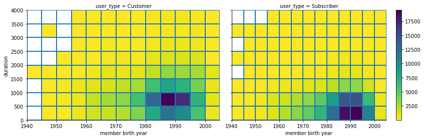

```python
bins_x = np.arange(1940, df['member_birth_year'].max()+5,5)
bins_y = np.arange(0, 4000+500,500)

g = sb.FacetGrid(data=df, col='user_type', size=4, aspect=1.5)
g.map(plt.hist2d, 'member_birth_year', 'duration_sec',bins=[bins_x,bins_y], cmin=0.5, cmap='viridis_r')
plt.colorbar()

g.set_xlabels('member birth year')
g.set_ylabels('duration')
```